# Mean-Variance Optimization

Tidy Asset Allocation in R, Chapter 9

Sebastian Stöckl

## Learning Outcomes

After this session we can

1. **State** the mean-variance problem and its two anchor solutions, and compute the two-asset minimum-variance weights by hand.
2. **Implement** the problem in `PortfolioAnalytics`, and **read** the picture it produces: assets, frontier, tangency line.
3. **Explain** why the minimum-variance end of the frontier is stable and the tangency end is not, and what a constraint costs.
4. **Evaluate** how much of the in-sample result survives out of sample.

## The Question

How should an investor divide wealth across assets that differ in expected return, in volatility, and in how they move together?

Markowitz (1952) answered that a portfolio cannot be judged asset by asset: the risk of the whole depends on the **covariances** between its parts as much as on the variances of each.

- Portfolio choice becomes an optimization problem with a closed-form solution.
- Every later method in the book departs from this point.
- This chapter is about **strategic allocation**: long-run, unconditional beliefs, no timing.

Markowitz, H. (1952). Portfolio Selection. *Journal of Finance* 7(1), 77–91.

## Data and Notation

The sixteen risky class series of the modeled market, 372 monthly returns each, in excess of the Treasury bill.

- $\boldsymbol{w}$: weights over $N$ assets; $\boldsymbol{\iota}$: a vector of ones
- $\boldsymbol{\mu}$: expected excess returns; $\boldsymbol{\Sigma}$: their covariance matrix

$$\mu_{\boldsymbol{w}} = \boldsymbol{w}'\boldsymbol{\mu},
\qquad
\sigma^2_{\boldsymbol{w}} = \boldsymbol{w}'\boldsymbol{\Sigma}\boldsymbol{w}.$$

The second expression is the whole of Markowitz (1952) in one line: the off-diagonal terms of $\boldsymbol{\Sigma}$ enter, and they can be negative.

## Dominance and Efficiency

In the plane with volatility on the horizontal axis and expected return on the vertical, portfolio $A$ **dominates** portfolio $B$ if

$$\mu_A \geq \mu_B \quad\text{and}\quad \sigma_A \leq \sigma_B,$$

with at least one inequality strict.

- A better portfolio always lies to the **northwest** of a worse one.
- A portfolio that no feasible portfolio dominates is **efficient**.
- The same vocabulary applies to single assets, before any optimizer runs.

## The Two-Asset Case

With $N = 2$ the minimum-variance weights need no matrix algebra. Write $\sigma_{12} = \rho\,\sigma_1\sigma_2$:

$$w_1 = \frac{\sigma_2^2 - \sigma_{12}}{\sigma_1^2 + \sigma_2^2 - 2\sigma_{12}},
\qquad w_2 = 1 - w_1 .$$

- The numerator rewards the asset whose covariance with the other is small relative to the other’s variance.
- The denominator is the variance of the difference of the two returns, $\mathrm{Var}(r_1 - r_2)$.
- At $\rho = \pm 1$ with $\sigma_1 \ne \sigma_2$ the attainable volatility is zero.

## Two Assets, Numbers Substituted

`US_equity` and `US_government`, annualized sample moments: $\sigma_1 = 0.1562$, $\sigma_2 = 0.0475$, $\rho = -0.14$, so $\sigma_{12} = -0.1370 \times 0.1562 \times 0.0475 = -0.00102$.

$$w_1 = \frac{0.00226 - -0.00102}
{0.02439 + 0.00226 - 2 \times -0.00102}
= 0.1142,
\qquad
w_2 = 0.8858.$$

$$\sigma_{\boldsymbol{w}}
= \sqrt{0.00032 + 0.00177 -0.00021}
= 0.0434 .$$

## Diversification in One Number

The portfolio’s volatility is 4.34%, against 4.75% for the less volatile constituent: 8.7% lower.

| correlation | equity weight | portfolio volatility |
| --- | --- | --- |
| -1.00 | 0.233 | 0.00% |
| -0.50 | 0.175 | 3.48% |
| 0.00 | 0.085 | 4.55% |
| -0.14 | 0.114 | 4.34% |
| 0.50 | -0.076 | 4.64% |
| 0.90 | -0.333 | 2.81% |
| 1.00 | -0.438 | 0.00% |

## The Mean-Variance Problem

For each attainable level of expected return $\bar{\mu}$, the investor wants the portfolio that achieves it at least variance:

$$\min_{\boldsymbol{w}} \; \boldsymbol{w}'\boldsymbol{\Sigma}\boldsymbol{w}
\quad \text{subject to} \quad
\boldsymbol{w}'\boldsymbol{\iota} = 1,
\quad
\boldsymbol{w}'\boldsymbol{\mu} = \bar{\mu}.$$

- The solutions, traced over $\bar{\mu}$, form the minimum-variance frontier.
- Its upper branch is the **efficient frontier**: no feasible portfolio dominates it.
- The lower branch is attainable but never chosen.

## Two Anchors with Closed Forms

**Minimum variance**: drop the return constraint.

$$\boldsymbol{w}_{\text{mv}}
= \frac{\boldsymbol{\Sigma}^{-1}\boldsymbol{\iota}}
{\boldsymbol{\iota}'\boldsymbol{\Sigma}^{-1}\boldsymbol{\iota}}$$

$\boldsymbol{\mu}$ does not appear: no view on returns is needed.

**Tangency**: with a risk-free asset, returns in excess of it.

$$\boldsymbol{w}_{\text{tan}}
= \frac{\boldsymbol{\Sigma}^{-1}\boldsymbol{\mu}}
{\boldsymbol{\iota}'\boldsymbol{\Sigma}^{-1}\boldsymbol{\mu}}$$

The highest Sharpe ratio; the same risky portfolio for every investor (Tobin, 1958).

With $A = \boldsymbol{\iota}'\boldsymbol{\Sigma}^{-1}\boldsymbol{\iota}$, $B = \boldsymbol{\iota}'\boldsymbol{\Sigma}^{-1}\boldsymbol{\mu}$, $C = \boldsymbol{\mu}'\boldsymbol{\Sigma}^{-1}\boldsymbol{\mu}$, the frontier is (Merton, 1972)

$$\sigma^2(\bar{\mu}) = \frac{A\bar{\mu}^2 - 2B\bar{\mu} + C}{AC - B^2}.$$

## The Sixteen Classes in the Volatility-Return Plane

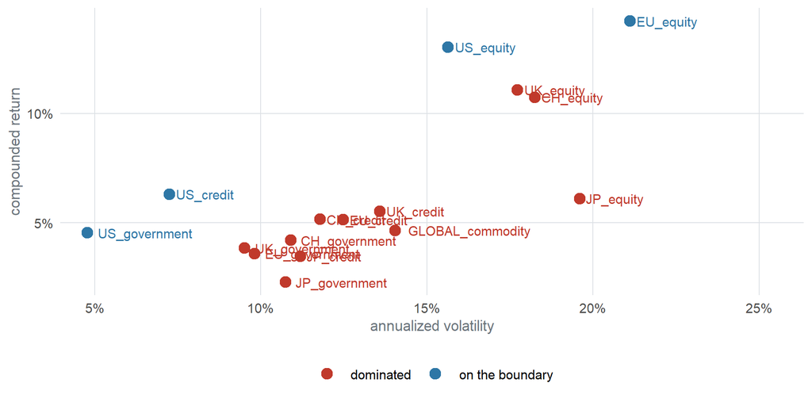

Figure 1

- 12 of 16 series are dominated by at least one other; the efficient ones are `EU_equity`, `US_equity`, `US_credit`, `US_government`.

## Specifying the Problem

A `portfolio.spec()` collects assets, constraints and objectives; `optimize.portfolio()` hands it to a solver.

```r
base_spec <- portfolio.spec(assets = colnames(Re)) |>
  add.constraint(type = "full_investment") |>   # weights sum to one
  add.constraint(type = "long_only")            # 0 <= w <= 1

min_var_spec <- base_spec |>
  add.objective(type = "risk", name = "var")

w_gmv <- extractWeights(optimize.portfolio(Re, min_var_spec, optimize_method = "ROI"))
round(w_gmv[w_gmv > 0.005], 4)
```

The solution holds 6 of the sixteen series and 82% of the money sits in `US_government`: volatility 4.13%, Sharpe ratio 0.80.

## From Closed Form to Quadratic Program

The closed forms assume weights of any sign and any size. Add $\boldsymbol{w} \geq \boldsymbol{0}$ and the analytic solution disappears; the problem is a convex **quadratic program**, solved to numerical precision in milliseconds.

- On the sixteen classes, the unconstrained minimum-variance solution holds 5 shorts, the largest in `UK_government` at -83.7%.
- Everything computed from here on is a quadratic program of this kind.
- Means and covariances are estimates, so the weights inherit their errors (Best and Grauer, 1991; Michaud, 1989).

## Reading the Frontier off the Optimizer

```r
ef_spec <- base_spec |>
  add.objective(type = "return", name = "mean") |>
  add.objective(type = "risk",   name = "StdDev")

ef <- create.EfficientFrontier(Re, ef_spec, type = "mean-StdDev", n.portfolios = 200)

# `ef$frontier` is a matrix carrying a class attribute, and `as.data.frame()`
# dispatches on that class: it returns every cell in a single column rather
# than one row of 19 per frontier portfolio. Strip the class first, or index it
# as the matrix it is.
fr <- as.data.frame(unclass(ef$frontier))
stopifnot(ncol(fr) == ncol(Re) + 3L)

# Returns are already in excess of the bill, so the Sharpe ratio is the ratio
# itself: no risk-free rate to subtract.
fr$sharpe <- fr$mean / fr$StdDev
i_tan <- which.max(fr$sharpe)

wcols <- grep("^w[.]", colnames(fr))
w_tan <- setNames(as.numeric(fr[i_tan, wcols]), sub("^w[.]", "", colnames(fr)[wcols]))
w_tan <- w_tan[colnames(Re)]
round(w_tan[w_tan > 0.005], 4)
```

The tangency portfolio is read off the frontier by its Sharpe ratio, rather than requested with `maxSR = TRUE`.

## The Anchors Against Two Alternatives

Table 1

|  | volatility | excess return | Sharpe | positions held |
| --- | --- | --- | --- | --- |
| Minimum variance | 4.13% | 3.29% | 0.795 | 6 |
| Tangency | 5.11% | 5.07% | 0.991 | 4 |
| 60/40 | 9.73% | 6.72% | 0.691 | 10 |
| Equal weight | 8.06% | 4.97% | 0.617 | 16 |

- In sample, the tangency portfolio has a Sharpe ratio 0.30 above a 60/40 allocation: a wide margin, and an in-sample one.
- It holds 0.4% in `US_credit`, the series with the most negative skewness (-1.45); variance cannot see it.

## The Frontier

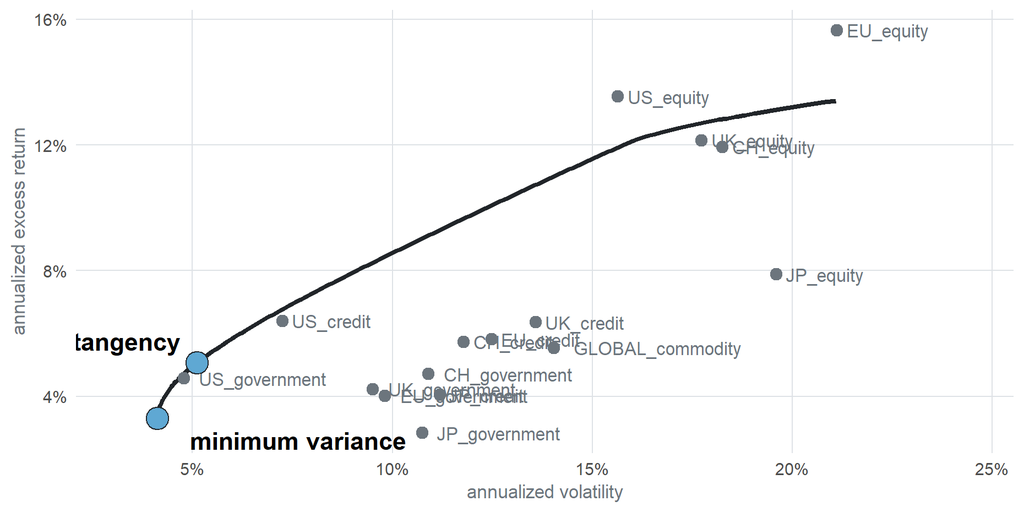

The left end is the minimum-variance portfolio; the right end holds a single asset, the one with the highest return.

## The Tangency Line

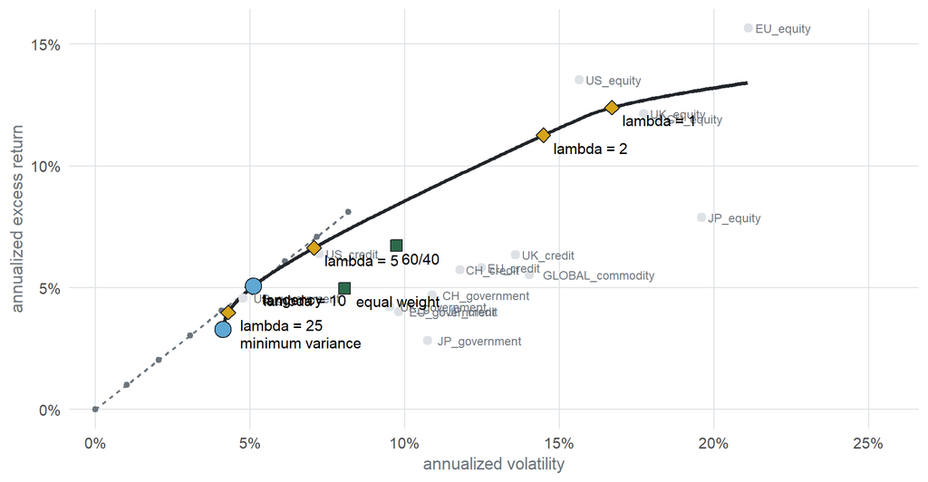

Figure 2

In excess-return space the capital allocation line starts at the origin and touches the frontier at the tangency portfolio.

## Weights Along the Frontier

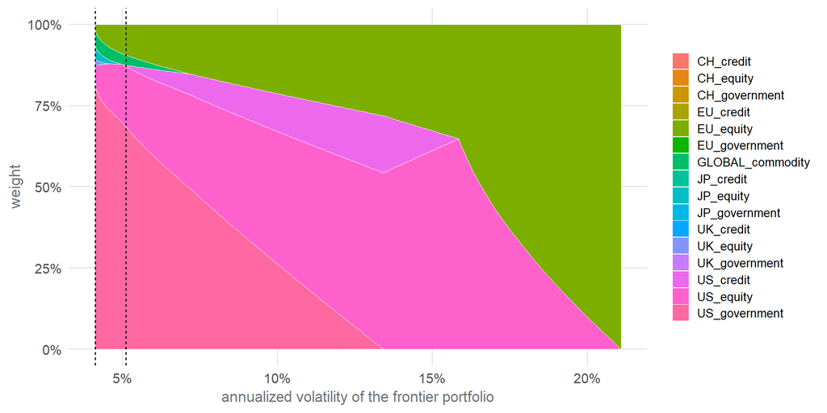

Figure 3

Government bonds dominate the left end, equity and credit the middle, and one equity market the right end.

## A Trap: The Exact Budget Constraint

**An exact budget constraint can be reported as infeasible**

On the CRAN release of `PortfolioAnalytics`, an exact `full_investment` constraint is encoded as two opposing inequality rows. `quadprog` then reports the problem infeasible and ROI returns `NA` weights without raising a condition.

Measured on this data: **30 of 312** rolling sixty-month minimum-variance windows fail, with nothing but $\boldsymbol{w}'\boldsymbol{\iota} = 1$ and $\boldsymbol{w} \geq \boldsymbol{0}$. The fix is pinned in the book’s package notes.

- The same release makes `maxSR = TRUE` unreliable, which is why the tangency portfolio is read off the frontier.
- Inside a rebalancing loop, guard every solve: the chapter’s `solve_checked()` stops on `NULL` or `NA` weights.

## Left End Stable, Right End Not

Block bootstrap, 200 draws of twelve-month blocks, re-optimized each time. Turnover is the share of the portfolio traded to reach the resampled answer.

Table 2

|  | mean | median | 95th percentile |
| --- | --- | --- | --- |
| Minimum variance | 0.062 | 0.059 | 0.111 |
| Tangency | 0.212 | 0.158 | 0.530 |

The tangency portfolio moves 3.4 times as far as minimum variance on the same data. Nothing changed except the sample.

## The Universe Sets the Floor

| universe | mean correlation | effective bets | minimum-variance volatility | below the least volatile asset |
| --- | --- | --- | --- | --- |
| 16 mixed classes | 0.34 | 1.47 | 4.1% | 13.6% |
| 5 equity classes | 0.55 | 3.49 | 13.8% | 11.4% |

- The portfolio with 2.4 times the effective positions buys the smaller discount.
- Across 521 sub-universes, the least volatile available asset explains 98% of the variation in the minimum-variance level; average correlation explains 5%.

## Out of Sample

Sixty-month rolling estimates, monthly rebalancing. The out-of-sample column is read from the backtesting chapter’s register.

Table 3

| portfolio | in_sample | out_of_sample | kept |
| --- | --- | --- | --- |
| Tangency | 0.991 | 0.546 | 0.551 |
| Minimum variance | 0.795 | 0.829 | 1.043 |
| Equal weight | 0.617 | 0.626 | 1.015 |

- The tangency portfolio keeps 55% of the Sharpe ratio it promised; minimum variance keeps 104%, which needed no estimate of $\boldsymbol{\mu}$.
- With 120 months behind each estimate the tangency portfolio reaches 0.70, ahead of equal weighting at 0.63 and behind minimum variance at 0.91.

## Key Takeaways

- **Outcome 1.** A closed form exists only without a short-sale constraint; with one, the problem is a quadratic program, which is what every result here solves.
- **Outcome 1.** The minimum-variance portfolio needs no return forecast, which is why it is far more stable than the tangency portfolio.
- **Outcome 2.** Concentration is not automatically a symptom of bad estimates: a dominant common factor produces it even with perfect inputs.
- **Outcome 3.** The left end of the frontier rests on $\boldsymbol{\Sigma}$, the right end on $\boldsymbol{\mu}$; a block bootstrap moves the tangency portfolio several times as far.
- **Outcome 3.** The level of minimum variance is set mainly by the least volatile asset available. Universe selection matters more than the weighting machinery.
- **Outcome 4.** The tangency portfolio is first in sample by construction; out of sample it keeps the smallest share of what it promised at every estimation window.

## Exercises

Work these in `code/09-mean-variance-exercises.R`; solutions are in appendix G of the book.

1. Add the five series of `sim_money_market_monthly` to the universe and recompute the anchors table. What happens to the minimum-variance portfolio?
2. Compute $\boldsymbol{\Sigma}^{-1}\boldsymbol{\iota}\,/\,\boldsymbol{\iota}'\boldsymbol{\Sigma}^{-1}\boldsymbol{\iota}$ directly and compare it with the `ROI` solution. Which constraint accounts for the difference?
3. Repeat the bootstrap with blocks of 1, 3 and 24 months. Which block length makes the tangency portfolio look most stable?
4. Replace `full_investment` with `weight_sum` bounded by 0.99 and 1.01, rerun minimum variance on every rolling sixty-month window, and count the failures. Then set the bounds to exactly one.
5. `US_credit` enters the frontier at the tangency portfolio. Compute its skewness and worst monthly return, and argue whether a loss-averse investor would hold it.